# C3_keras

## Redes neuronales

### Clase3: Predicción de valores continuos

**Autor: Luis Fernando Apáez Álvarez**

#### Contenido

Regresión lineal

Implementación de una red neuronal

Modelos con más variables regresoras

En esta clase realizaremos la implementación de un modelo de red neuronal para predicción de un valor continuo. Para ello trabajaremos con el conjunto de datos iris:

```python
import seaborn as sns

print('Conjuntos de datos disponibles en seaborn: ')
for _ in sns.get_dataset_names():
    print(_, end=', ')
```

```
Conjuntos de datos disponibles en seaborn:
anagrams, anscombe, attention, brain_networks, car_crashes, diamonds, dots, dowjones, exercise, flights, fmri, geyser, glue, healthexp, iris, mpg, penguins, planets, seaice, taxis, tips, titanic,
```

```python
# cargamos el conjunto de datos iris
df = sns.load_dataset('iris')
df.head()
```

|  | sepal_length | sepal_width | petal_length | petal_width | species |
| --- | --- | --- | --- | --- | --- |
| 0 | 5.1 | 3.5 | 1.4 | 0.2 | setosa |
| 1 | 4.9 | 3.0 | 1.4 | 0.2 | setosa |
| 2 | 4.7 | 3.2 | 1.3 | 0.2 | setosa |
| 3 | 4.6 | 3.1 | 1.5 | 0.2 | setosa |
| 4 | 5.0 | 3.6 | 1.4 | 0.2 | setosa |

Y consideraremos un dataframe con las correlaciones ntre dichas variables

```python
df.corr(method='pearson')
```

|  | sepal_length | sepal_width | petal_length | petal_width |
| --- | --- | --- | --- | --- |
| sepal_length | 1.000000 | -0.117570 | 0.871754 | 0.817941 |
| sepal_width | -0.117570 | 1.000000 | -0.428440 | -0.366126 |
| petal_length | 0.871754 | -0.428440 | 1.000000 | 0.962865 |
| petal_width | 0.817941 | -0.366126 | 0.962865 | 1.000000 |

Notamos que `petal_width` con `petal_length` están altamente correlacionadas. Gráficamente

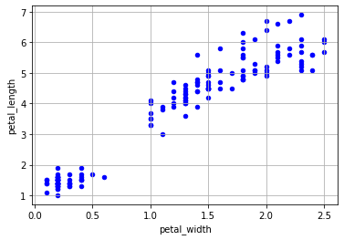

```python
ax = df.plot.scatter(x='petal_width', y='petal_length', c='blue', grid=True)
```

Para la primera parte de esta clase trabajaremos únicamente con las dos variables anteriores

```python
# seleccionamos solo las dos variables de interes
df_reducido = df[['petal_width', 'petal_length']]
```

### Regresión lineal

Lo que haremos inicialmente será implementar un modelo de regresión lineal simple, donde `petal_width` será la variable regresora y `petal_length` será la variable de respuesta. Después de ajustar el modelo de regresión con los datos de entrenamiento, realizaremos predicciones sobre el conjunto de prueba. Para ello

#### División de los datos

```python
# Importacion necesaria
from sklearn.model_selection import train_test_split

# definimos las variables
X = df['petal_width'].values.reshape(-1,1)
y = df['petal_length'].values.reshape(-1,1)

# division de los datos
X_train, X_test, y_train, y_test = train_test_split(X, y, # conjunto completo
                                       test_size=0.25,    # 25% para pruebas
                                       random_state=123)  # semilla aleatoria
```

Procedemos a realizar el modelo de regresión y el ajuste

```python
from sklearn.linear_model import LinearRegression

# instanciamos
reg = LinearRegression()

# ajustamos sobre los datos de entrenamiento
reg.fit(X_train, y_train)
```

```
LinearRegression()
```

Realizamos ahora la predicción sobre el conjunto de pruebas y comparamos resultados mediante un dataframe

```python
# predicion
y_pred_regression = reg.predict(X_test)

# dataframe con la informacion
df_info = pd.DataFrame(y_pred_regression).rename(columns = {0: 'y_pred_reg'})
df_info['y_test'] = y_test
df_info = df_info.reset_index()
# calculamos las diferencias entre los valores reales y los predichos
df_info['diff'] = abs(df_info.y_pred_reg - df_info.y_test)
# calculamos el porcentaje de error para cada fila
df_info['error'] = (df_info['diff'] * 100) / df_info['y_test']
df_info.head()
```

|  | index | y_pred_reg | y_test | diff | error |
| --- | --- | --- | --- | --- | --- |
| 0 | 0 | 4.409119 | 4.9 | 0.490881 | 10.017988 |
| 1 | 1 | 5.736517 | 5.5 | 0.236517 | 4.300308 |
| 2 | 2 | 5.957750 | 5.6 | 0.357750 | 6.388392 |
| 3 | 3 | 3.966653 | 4.1 | 0.133347 | 3.252378 |
| 4 | 4 | 1.311856 | 1.4 | 0.088144 | 6.296008 |

Veamos un dataframe con estadísticas sobre la información anterior

```python
df_info.describe()
```

|  | index | y_pred_reg | y_test | diff | error |
| --- | --- | --- | --- | --- | --- |
| count | 38.000000 | 38.000000 | 38.000000 | 38.000000 | 38.000000 |
| mean | 18.500000 | 3.489255 | 3.544737 | 0.356043 | 11.113797 |
| std | 11.113055 | 1.801369 | 1.911374 | 0.264684 | 6.819835 |
| min | 0.000000 | 1.311856 | 1.100000 | 0.002953 | 0.089495 |
| 25% | 9.250000 | 1.533089 | 1.425000 | 0.133154 | 6.319104 |
| 50% | 18.500000 | 3.856036 | 4.050000 | 0.274186 | 9.833552 |
| 75% | 27.750000 | 5.072818 | 5.075000 | 0.506806 | 14.613545 |
| max | 37.000000 | 6.178983 | 6.700000 | 1.078983 | 31.703670 |

Tenemos que el error porcentual (el referente a la columna `error`) fue en promedio del 11.11%; el error máximo fue del 31.7% y el mínimo del 0.08%. El 75% de los errores fue menor al 14.61% y el 50% de los errores fue menor al 9.83%. De tal manera, parece ser que el ajuste de la regresión sobre los datos fue muy bueno. Podemos comprobar dicho rendimiento mediante las siguientes métricas

```python
from sklearn.metrics import mean_squared_error
from sklearn.metrics import r2_score

# error cuadratico medio
mse = mean_squared_error(y_pred_regression, y_test)
# R^2
r2 = r2_score(y_pred_regression, y_test)
# veamos
print(f'mse = {mse}\nR^2 = {r2}')
```

```
mse = 0.19498031795213722
R^2 = 0.9382883033472239
```

tenemos que el mse es pequeño y la $R^{2}$ es cercana a 1, de donde tenemos que el modelo de regresión obtenido es muy bueno.

Podemos ver un gráfico para observar qué tan buenas fueron nuestras predicciones. Para ello realizaremos un gráfico de líneas como sigue:

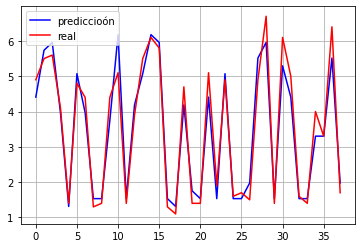

```python
plt.plot(df_info.index, df_info.y_pred_reg, color='blue', label='prediccioón')
plt.plot(df_info.index, df_info.y_test, color='red', label='real')
plt.legend()
plt.grid()
plt.show()
```

Podemos observar un ajuste muy bueno de la predicción a los valores reales.

Lo que haremos después será la implementación de una red neuronal para predecir los valores de la variable `petal_length`.

### Implementación de una red neuronal

En esta ocasión utilizaremos sólo la función de activación ReLu:

$$ ReLu(x)=max(0, x) $$

[figure not shown]

dado que querremos mantener los valores continuos que le vayamos pasando a la red. Por ejemplo, no sería conveniente utilizar la función de activación sigmoide debido a que ésta se utiliza para problemas de clasificación binaria.

Además, para problemas de predición de valores continuas, es común utilizar la función de pérdida del error cuadrático medio.

De tal manera, definimos la siguiente función:

```python
from keras.models import Sequential
from keras.layers import Dense

def modelo(n1, n2, activacion, epocas, boolean):
    """
    n1: número de neuronas en la primer capa
    n2: número de neuronas en la segunda capa
    activacion: función de activación en la última capa
    epocas: número de épocas
    boolean: booleano para determinar el valor de verbose
    """
    # Instanciamos el modelo
    model = Sequential()
    # Capa de entrada de 1 neurona y capa oculta de n1 neuronas.
    # Para la capa oculta utilizamos la funcion de activacion relu
    model.add(Dense(n1, activation='relu', input_shape=(1,)))
    # Capa oculta 2:
    # n2 neuronas y funcion de activacion relu
    model.add(Dense(n2, activation='relu'))
    # Capa de salida con funcion de activacion "activacion"
    model.add(Dense(1, activation=activacion))
    # Compilacion. Utilizaremos ahora el error cuadratico medio
    model.compile(optimizer='adam', loss='mean_squared_error')
    # Entrenamiento
    modelo = model.fit(X_train, y_train, epochs=epocas, verbose = boolean)
    # prediccion
    y_pred = model.predict(X_test)
    # dataframe con la informacion
    df = pd.DataFrame(y_pred).rename(columns = {0: 'y_pred'})
    df['y_test'] = y_test
    df = df.reset_index()
    df['diff'] = abs(df.y_pred - df.y_test)
    df['error'] = (df['diff'] * 100) / df['y_test']
    # estadisticas
    df_stats = df.describe()
    # grafica
    plt.plot(df.index, df.y_pred, color='blue', label='prediccioón')
    plt.plot(df.index, df.y_test, color='red', label='real')
    plt.legend()
    plt.grid()
    plt.show()
    # MSE
    mse = mean_squared_error(y_pred, y_test)
    print(f'mse = {mse}')
    return modelo, df, df_stats
```

Implementamos un primer modelo

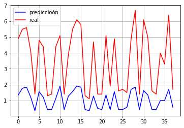

```
mse = 8.024392817825545
```

|  | index | y_pred | y_test | diff | error |
| --- | --- | --- | --- | --- | --- |
| count | 38.000000 | 38.000000 | 38.000000 | 38.000000 | 38.000000 |
| mean | 18.500000 | 1.048651 | 3.544737 | 2.496086 | 70.268226 |
| std | 11.113055 | 0.575967 | 1.911374 | 1.357362 | 3.610582 |
| min | 0.000000 | 0.349918 | 1.100000 | 0.750082 | 62.309921 |
| 25% | 9.250000 | 0.423397 | 1.425000 | 0.994972 | 67.671770 |
| 50% | 18.500000 | 1.166187 | 4.050000 | 2.954499 | 69.757323 |
| 75% | 27.750000 | 1.554964 | 5.075000 | 3.632096 | 73.297980 |
| max | 37.000000 | 1.908396 | 6.700000 | 4.862290 | 77.715922 |

```python
modelo1, df1, df_stats1 = modelo(40, 25, 'relu', 13, True)
df_stats1
```

con el cual obtenemos malos resultados.

Ahora, en vez de utilizar la función de activación ReLu utilizaremos la siguiente variante:

$$ LeakyReLU(x)=\left\{\begin{array}{c}x, x>0\\ \ 0, mx<0\end{array}\right. $$

donde ésta en vez de enviar valores negativos a cero utiliza un parámetro de pendiente muy pequeño que incorpora cierta información de valores negativos. El problema que tenía nuestra red neuronal era justamente ese, en el cual los valores negativos se estaban yendo todos a cero, problema el cual queda solucionado con la función de activación ReLU con fugas (o 𝐿𝑒𝑎𝑘𝑦𝑅𝑒𝐿𝑈). Un detalle importante por mencionar es que con la función de activación ReLu la convergencia es más rápida, no obstante, para la ReLu con fugas dicha convergencia será un poco más lenta, de modo que implementaremos un mayor número de épocas.

De tal manera escribiremos

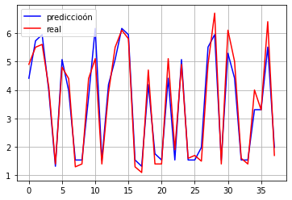

```
mse = 0.19440326062005897
```

|  | index | y_pred | y_test | diff | error |
| --- | --- | --- | --- | --- | --- |
| count | 38.000000 | 38.000000 | 38.000000 | 38.000000 | 38.000000 |
| mean | 18.500000 | 3.489606 | 3.544737 | 0.355140 | 11.158327 |
| std | 11.113055 | 1.794334 | 1.911374 | 0.264809 | 6.957903 |
| min | 0.000000 | 1.318692 | 1.100000 | 0.007195 | 0.218022 |
| 25% | 9.250000 | 1.539637 | 1.425000 | 0.139637 | 5.891013 |
| 50% | 18.500000 | 3.859528 | 4.050000 | 0.275254 | 9.974061 |
| 75% | 27.750000 | 5.068981 | 5.075000 | 0.504230 | 14.585636 |
| max | 37.000000 | 6.162619 | 6.700000 | 1.062619 | 32.101742 |

```python
modelo2, df2, df_stats2 = modelo(40, 25, 'LeakyReLU', 50, False)
df_stats2
```

con lo cual obtenemos mejores resultados, en realidad, dichos resultados son muy similares a los obtenidos con el modelo de regresión.

Recordemos que la función ReLu con fugas tiene un parámetro $m$ referente a la pendiente. Para modificar dicho valor podemos recurrir a tensorflow:

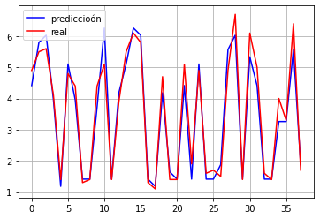

```
mse = 0.19706047023275194
```

|  | index | y_pred | y_test | diff | error |
| --- | --- | --- | --- | --- | --- |
| count | 38.000000 | 38.000000 | 38.000000 | 38.000000 | 38.000000 |
| mean | 18.500000 | 3.454379 | 3.544737 | 0.348974 | 9.870676 |
| std | 11.113055 | 1.880185 | 1.911374 | 0.278051 | 6.661151 |
| min | 0.000000 | 1.181068 | 1.100000 | 0.012454 | 0.889572 |
| 25% | 9.250000 | 1.412454 | 1.425000 | 0.150619 | 4.534514 |
| 50% | 18.500000 | 3.837573 | 4.050000 | 0.285695 | 9.947510 |
| 75% | 27.750000 | 5.107232 | 5.075000 | 0.509004 | 13.324466 |
| max | 37.000000 | 6.261467 | 6.700000 | 1.161467 | 25.660315 |

```python
import tensorflow as tf

# ReLu con fugas configurando el valor de la pendiente m (alpha)
fun_activacion = lambda x: tf.keras.layers.LeakyReLU(alpha=x)

# alpha=0.3
modelo3, df3, df_stats3 = modelo(40, 25, fun_activacion(0.3), 50, False)
df_stats3
```

notamos que con dicho valor hemos mejorado el modelo en cuanto al error promedio, el valor del cuartil al 75% y el valor máximo del error ha disminuido, en comparativa con el modelo de regresión. Así, hemos obtenido un mejor modelo con la red neuronal.

Continuamos en la búsqueda por el mejor modelo

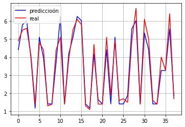

```
mse = 0.19659494009660292
```

|  | index | y_pred | y_test | diff | error |
| --- | --- | --- | --- | --- | --- |
| count | 38.000000 | 38.000000 | 38.000000 | 38.000000 | 38.000000 |
| mean | 18.500000 | 3.451361 | 3.544737 | 0.347851 | 9.836075 |
| std | 11.113055 | 1.877487 | 1.911374 | 0.278636 | 6.686215 |
| min | 0.000000 | 1.179924 | 1.100000 | 0.011312 | 0.807965 |
| 25% | 9.250000 | 1.411312 | 1.425000 | 0.147839 | 4.419739 |
| 50% | 18.500000 | 3.838183 | 4.050000 | 0.285953 | 10.035467 |
| 75% | 27.750000 | 5.102206 | 5.075000 | 0.509759 | 13.378070 |
| max | 37.000000 | 6.250940 | 6.700000 | 1.150940 | 25.720447 |

```python
# alpha=0.4
modelo4, df4, df_stats4 = modelo(40, 25, fun_activacion(0.4), 50, False)
df_stats4
```

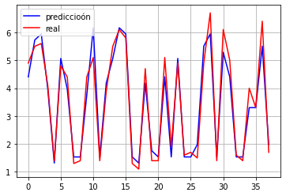

```
mse = 0.19503224669142566
```

|  | index | y_pred | y_test | diff | error |
| --- | --- | --- | --- | --- | --- |
| count | 38.000000 | 38.000000 | 38.000000 | 38.000000 | 38.000000 |
| mean | 18.500000 | 3.486083 | 3.544737 | 0.355092 | 11.103247 |
| std | 11.113055 | 1.796349 | 1.911374 | 0.266092 | 6.860370 |
| min | 0.000000 | 1.314304 | 1.100000 | 0.002903 | 0.087982 |
| 25% | 9.250000 | 1.534458 | 1.425000 | 0.134458 | 6.131354 |
| 50% | 18.500000 | 3.855724 | 4.050000 | 0.270635 | 9.800012 |
| 75% | 27.750000 | 5.065818 | 5.075000 | 0.509000 | 14.651458 |
| max | 37.000000 | 6.164742 | 6.700000 | 1.064742 | 31.696852 |

```python
# alpha=0.7
modelo5, df5, df_stats5 = modelo(40, 25, fun_activacion(0.7), 50, False)
df_stats5
```

Al aumentar el valor de alpha en 0.7 tenemos un peor rendimiento comparado con el modelo donde alpha=0.4.

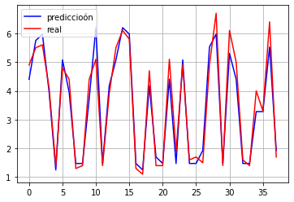

```
mse = 0.1948398463071247
```

|  | index | y_pred | y_test | diff | error |
| --- | --- | --- | --- | --- | --- |
| count | 38.000000 | 38.000000 | 38.000000 | 38.000000 | 38.000000 |
| mean | 18.500000 | 3.465775 | 3.544737 | 0.351841 | 10.496029 |
| std | 11.113055 | 1.832457 | 1.911374 | 0.270126 | 6.207114 |
| min | 0.000000 | 1.249901 | 1.100000 | 0.021658 | 0.656296 |
| 25% | 9.250000 | 1.474990 | 1.425000 | 0.146613 | 5.356446 |
| 50% | 18.500000 | 3.841792 | 4.050000 | 0.263687 | 10.423440 |
| 75% | 27.750000 | 5.077075 | 5.075000 | 0.514457 | 13.460788 |
| max | 37.000000 | 6.199116 | 6.700000 | 1.099116 | 28.404196 |

```python
# alpha=0.4
modelo6, df6, df_stats6 = modelo(40, 25, fun_activacion(0.4), 70, False)
df_stats6
```

Tampoco parece ser lo correcto aumentar el número de épocas.

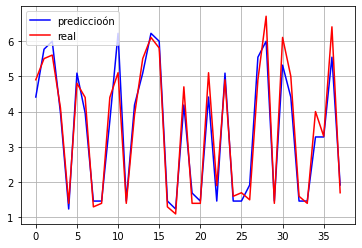

```
mse = 0.19387595750027908
```

|  | index | y_pred | y_test | diff | error |
| --- | --- | --- | --- | --- | --- |
| count | 38.000000 | 38.000000 | 38.000000 | 38.000000 | 38.000000 |
| mean | 18.500000 | 3.467559 | 3.544737 | 0.350933 | 10.381939 |
| std | 11.113055 | 1.843523 | 1.911374 | 0.269506 | 6.190502 |
| min | 0.000000 | 1.239383 | 1.100000 | 0.019914 | 0.603461 |
| 25% | 9.250000 | 1.464303 | 1.425000 | 0.139465 | 4.651673 |
| 50% | 18.500000 | 3.847175 | 4.050000 | 0.275724 | 10.286566 |
| 75% | 27.750000 | 5.088551 | 5.075000 | 0.507647 | 13.014203 |
| max | 37.000000 | 6.216816 | 6.700000 | 1.116816 | 27.876862 |

```python
# alpha=0.4
modelo7, df7, df_stats7 = modelo(30, 20, fun_activacion(0.4), 70, False)
df_stats7
```

ni dismiuir el número de neuronas. Aunque en los modelos anterior no obtenemos como tal un mal modelo.

Obtamos entonces por quedarnos con el modelo 4:

```python
df_stats4
```

|  | index | y_pred | y_test | diff | error |
| --- | --- | --- | --- | --- | --- |
| count | 38.000000 | 38.000000 | 38.000000 | 38.000000 | 38.000000 |
| mean | 18.500000 | 3.451361 | 3.544737 | 0.347851 | 9.836075 |
| std | 11.113055 | 1.877487 | 1.911374 | 0.278636 | 6.686215 |
| min | 0.000000 | 1.179924 | 1.100000 | 0.011312 | 0.807965 |
| 25% | 9.250000 | 1.411312 | 1.425000 | 0.147839 | 4.419739 |
| 50% | 18.500000 | 3.838183 | 4.050000 | 0.285953 | 10.035467 |
| 75% | 27.750000 | 5.102206 | 5.075000 | 0.509759 | 13.378070 |
| max | 37.000000 | 6.250940 | 6.700000 | 1.150940 | 25.720447 |

Recordemos que tanto la regresión lineal simple como el modelo de la red neurona solo ocuparon una variable con variable regresora. Lo que haremos ahora será la implementación de más variables predictorias. Así, la regresión lineal simple pasará a ser ahora una regresión lineal múltiple.

### Modelos con más variables regresoras

#### Regresión lineal múltiple

Dado que efectuaremos también una regresión lineal, tendremos que dicha regresión será múltiple. En este caso mantendremos a `petal_length` como la variable de respuesta y consideraremos al resto (menos la variable `species`) como variables predictorias.

```python
# Variables predictorias
X = df.drop(['petal_length', 'species'], axis=1).values
# variable de respuesta
y = df['petal_length'].values.reshape(-1,1)

# division de los datos
X_train, X_test, y_train, y_test = train_test_split(X, y, # conjunto completo
                                       test_size=0.25,    # 25% para pruebas
                                       random_state=123)  # semilla aleatoria
# instanciamos
reg = LinearRegression()

# ajustamos sobre los datos de entrenamiento
reg.fit(X_train, y_train)
```

```
LinearRegression()
```

De nuevo creamos un dataframe con los valores predichos y con los valores de `y_test`

```python
# predicion
y_pred_regression = reg.predict(X_test)

# dataframe con la informacion
df_info = pd.DataFrame(y_pred_regression).rename(columns = {0: 'y_pred_reg'})
df_info['y_test'] = y_test
df_info = df_info.reset_index()
# calculamos las diferencias entre los valores reales y los predichos
df_info['diff'] = abs(df_info.y_pred_reg - df_info.y_test)
# calculamos el porcentaje de error para cada fila
df_info['error'] = (df_info['diff'] * 100) / df_info['y_test']
df_info.head()
```

|  | index | y_pred_reg | y_test | diff | error |
| --- | --- | --- | --- | --- | --- |
| 0 | 0 | 4.910943 | 4.9 | 0.010943 | 0.223320 |
| 1 | 1 | 5.797656 | 5.5 | 0.297656 | 5.411921 |
| 2 | 2 | 5.776232 | 5.6 | 0.176232 | 3.147003 |
| 3 | 3 | 3.749124 | 4.1 | 0.350876 | 8.557963 |
| 4 | 4 | 1.092527 | 1.4 | 0.307473 | 21.962350 |

```python
df_info.describe()
```

|  | index | y_pred_reg | y_test | diff | error |
| --- | --- | --- | --- | --- | --- |
| count | 38.000000 | 38.000000 | 38.000000 | 38.000000 | 38.000000 |
| mean | 18.500000 | 3.513231 | 3.544737 | 0.261164 | 9.621598 |
| std | 11.113055 | 1.925357 | 1.911374 | 0.232472 | 9.685099 |
| min | 0.000000 | 1.054751 | 1.100000 | 0.005467 | 0.089624 |
| 25% | 9.250000 | 1.492094 | 1.425000 | 0.058166 | 2.747729 |
| 50% | 18.500000 | 3.802773 | 4.050000 | 0.190130 | 6.897631 |
| 75% | 27.750000 | 4.906221 | 5.075000 | 0.363613 | 13.271660 |
| max | 37.000000 | 6.763899 | 6.700000 | 0.989029 | 35.823164 |

Notamos que el error promedio es menor en comparativa con el modelo de regresión lineal simple, aunque la desviación estándar y el error máximo aumentaron para el caso de la regresión lineal múltiple.

Veamos algunas métricas:

```python
# error cuadratico medio
mse = mean_squared_error(y_pred_regression, y_test)
# R^2
r2 = r2_score(y_pred_regression, y_test)
# veamos
print(f'mse = {mse}\nR^2 = {r2}')
```

```
mse = 0.12082769704546548
R^2 = 0.9665245914976561
```

donde tenemos que:

| métrica | reg lineal simple | reg lineal múltiple |
| --- | --- | --- |
| $mse$ | 0.1949 | 0.1208 |
| $R^2$ | 0.938 | 0.9665 |

es decir, tenemos mejores resultados con el modelo de regresión lineal múltiple. Finalemnte veamos el gráfico de los datos reales versus los predichos

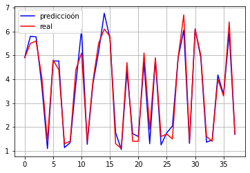

```python
plt.plot(df_info.index, df_info.y_pred_reg, color='blue', label='prediccioón')
plt.plot(df_info.index, df_info.y_test, color='red', label='real')
plt.legend()
plt.grid()
plt.show()
```

en el cual sí notamos una mejora en el ajuste comparando dicha gráfica con la obtenida en la regresión lineal simple:

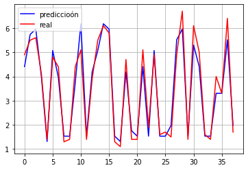

#### Modelo de la red neuronal

Realizaremos un pequeño cambia para `input_shape` en la siguiente función

```python
def modelo(n1, n2, activacion, epocas, boolean):
    """
    n1: número de neuronas en la primer capa
    n2: número de neuronas en la segunda capa
    activacion: función de activación en la última capa
    epocas: número de épocas
    boolean: booleano para determinar el valor de verbose
    """
    # Instanciamos el modelo
    model = Sequential()
    # Capa de entrada de 1 neurona y capa oculta de n1 neuronas.
    # Para la capa oculta utilizamos la funcion de activacion relu
    model.add(Dense(n1, activation='relu', input_shape=(3,)))
    # Capa oculta 2:
    # n2 neuronas y funcion de activacion relu
    model.add(Dense(n2, activation='relu'))
    # Capa de salida con funcion de activacion "activacion"
    model.add(Dense(1, activation=activacion))
    # Compilacion. Utilizaremos ahora el error cuadratico medio
    model.compile(optimizer='adam', loss='mean_squared_error')
    # Entrenamiento
    modelo = model.fit(X_train, y_train, epochs=epocas, verbose = boolean)
    # prediccion
    y_pred = model.predict(X_test)
    # dataframe con la informacion
    df = pd.DataFrame(y_pred).rename(columns = {0: 'y_pred'})
    df['y_test'] = y_test
    df = df.reset_index()
    df['diff'] = abs(df.y_pred - df.y_test)
    df['error'] = (df['diff'] * 100) / df['y_test']
    # estadisticas
    df_stats = df.describe()
    # grafica
    plt.plot(df.index, df.y_pred, color='blue', label='prediccioón')
    plt.plot(df.index, df.y_test, color='red', label='real')
    plt.legend()
    plt.grid()
    plt.show()
    # MSE
    mse = mean_squared_error(y_pred, y_test)
    print(f'mse = {mse}')
    return modelo, df, df_stats
```

pues recordemos que ahora estamos trabajando con 3 variables predictorias. Luego, implementamos los mismos valores configurados en el modelo 4

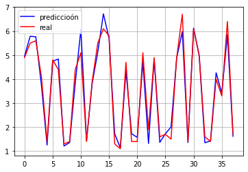

```
mse = 0.11747747303302854
```

|  | index | y_pred | y_test | diff | error |
| --- | --- | --- | --- | --- | --- |
| count | 38.000000 | 38.000000 | 38.000000 | 38.000000 | 38.000000 |
| mean | 18.500000 | 3.527997 | 3.544737 | 0.253141 | 8.675280 |
| std | 11.113055 | 1.903661 | 1.911374 | 0.234180 | 8.862192 |
| min | 0.000000 | 1.136449 | 1.100000 | 0.017433 | 0.355767 |
| 25% | 9.250000 | 1.475468 | 1.425000 | 0.051992 | 2.398264 |
| 50% | 18.500000 | 3.828365 | 4.050000 | 0.169351 | 6.640920 |
| 75% | 27.750000 | 4.959173 | 5.075000 | 0.377703 | 10.674295 |
| max | 37.000000 | 6.720815 | 6.700000 | 0.962185 | 33.820804 |

```python
# Para este caso aumentamos el numero de epocas
modelo1_mult, df1_mult, df_stats1_mult = modelo(40, 25, fun_activacion(0.4), 70, False)
df_stats1_mult
```

Notamos también una mejora respecto al resultado obtenido en el modelo 4 (en el cual solo trabajamos con una variable predictoria):

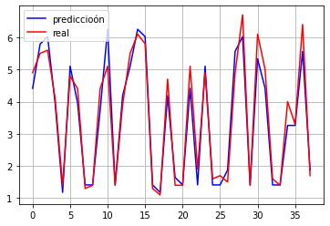

Podemos comparar estadísticas del modelo 4 con una variable predictoria, al modelo implementado antes con 3 variables predictorias

```python
display(df_stats4)
print()
display(df_stats1_mult)
```

|  | index | y_pred | y_test | diff | error |
| --- | --- | --- | --- | --- | --- |
| count | 38.000000 | 38.000000 | 38.000000 | 38.000000 | 38.000000 |
| mean | 18.500000 | 3.451361 | 3.544737 | 0.347851 | 9.836075 |
| std | 11.113055 | 1.877487 | 1.911374 | 0.278636 | 6.686215 |
| min | 0.000000 | 1.179924 | 1.100000 | 0.011312 | 0.807965 |
| 25% | 9.250000 | 1.411312 | 1.425000 | 0.147839 | 4.419739 |
| 50% | 18.500000 | 3.838183 | 4.050000 | 0.285953 | 10.035467 |
| 75% | 27.750000 | 5.102206 | 5.075000 | 0.509759 | 13.378070 |
| max | 37.000000 | 6.250940 | 6.700000 | 1.150940 | 25.720447 |

|  | index | y_pred | y_test | diff | error |
| --- | --- | --- | --- | --- | --- |
| count | 38.000000 | 38.000000 | 38.000000 | 38.000000 | 38.000000 |
| mean | 18.500000 | 3.527997 | 3.544737 | 0.253141 | 8.675280 |
| std | 11.113055 | 1.903661 | 1.911374 | 0.234180 | 8.862192 |
| min | 0.000000 | 1.136449 | 1.100000 | 0.017433 | 0.355767 |
| 25% | 9.250000 | 1.475468 | 1.425000 | 0.051992 | 2.398264 |
| 50% | 18.500000 | 3.828365 | 4.050000 | 0.169351 | 6.640920 |
| 75% | 27.750000 | 4.959173 | 5.075000 | 0.377703 | 10.674295 |
| max | 37.000000 | 6.720815 | 6.700000 | 0.962185 | 33.820804 |

notamos mejoras en el modelo `modelo1_mult`, pero el modelo 4 mantiene un menor número referente a la desviacón estándar y al error máximo cometido. De tal manera vemos que cada modelo tendrá sus ventajas y desventajas.